# Size Factor Normalisation

Here we are going to look at how to perform a size factor normalisation in R. This is one of the more robust ways to normalise a dataset which shows skewed distributions of differences between samples, and where traditional global normalisation might perform poorly.

# Setup

We’re going to use the tidyverse framework for loading, manipulating and plotting our data.

```r
library(tidyverse)
theme_set(theme_bw())
```

# Loading Data

We’ve got some example data with three samples

1. Wild type
2. Knockout
3. Rescue

Let’s see what it looks like.

```r
read_delim("size_factor_data.txt") -> data

head(data)
```

| gene | KO | Rescue | WT |
| --- | --- | --- | --- |
| gene_4 | 0 | 0 | 0 |
| gene_6 | 0 | 0 | 1 |
| gene_7 | 1 | 0 | 5 |
| gene_9 | 0 | 0 | 0 |
| gene_15 | 11 | 22 | 39 |
| gene_16 | 3 | 6 | 8 |

We can plot out the relationships of the different samples to the WT

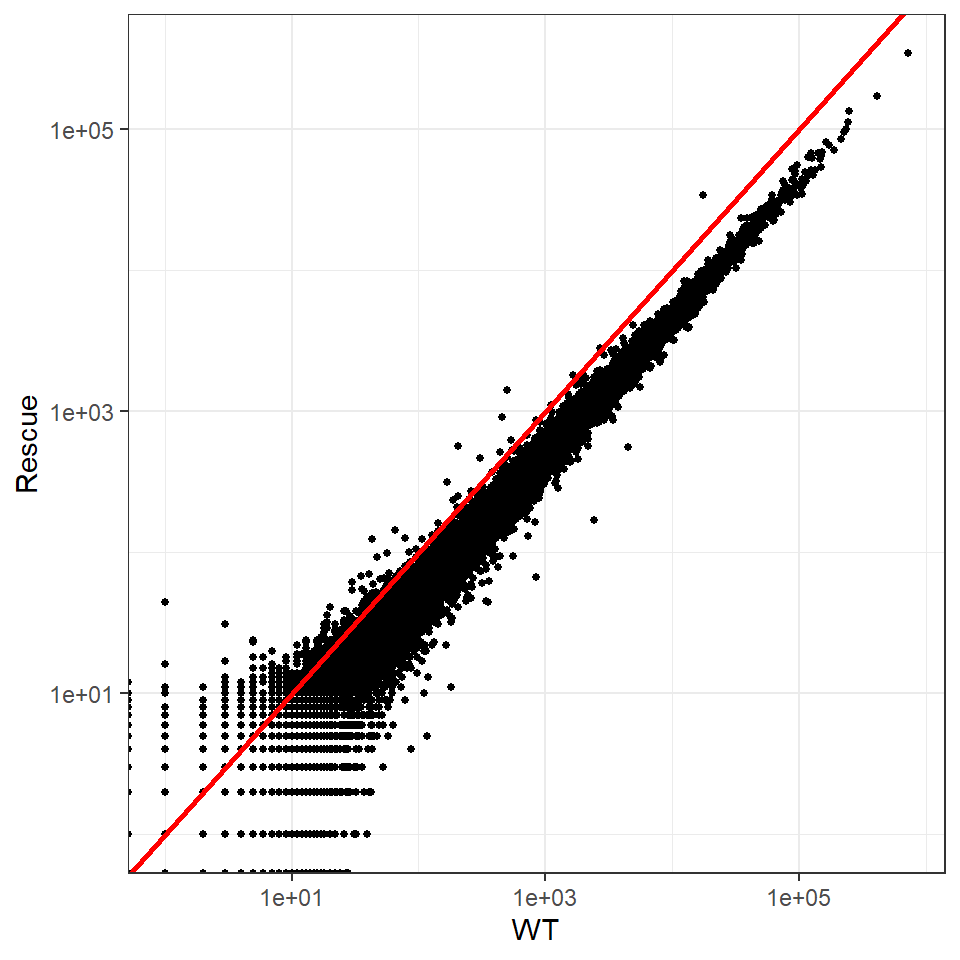

```r
data %>%
  ggplot(aes(x=WT, y=Rescue)) +
  geom_point(size=1) +
  scale_x_log10() + scale_y_log10() +
  geom_abline(slope=1, intercept=0, colour="red", linewidth=1)
```

For the WT vs Rescue we can see a similar overall structure to the data, but with a global offset which needs to be corrected.

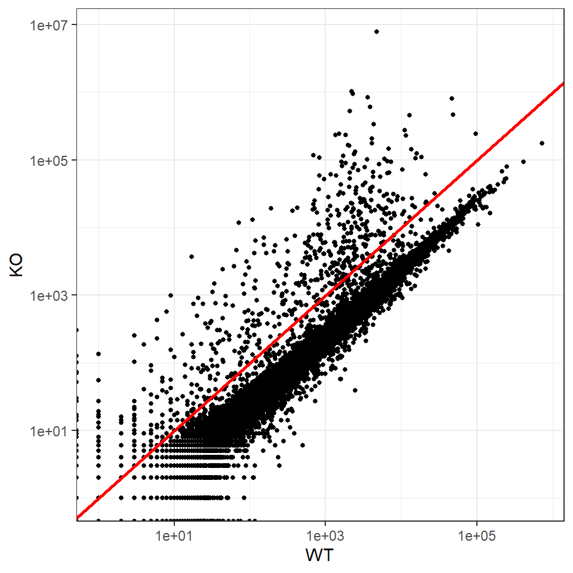

```r
data %>%
  ggplot(aes(x=WT, y=KO)) +
  geom_point(size=1) +
  scale_x_log10() + scale_y_log10() +
  geom_abline(slope=1, intercept=0, colour="red", linewidth=1)
```

For the WT vs KO we can see many more changes, and a very substantial directional skew with pretty much all of the changes being higher in the KO.

# Global Normalisation

A conventional normalisation is based on the sum of the values in each sample so let’s try that and see what we get.

We’ll start by restructing the data to long format.

```r
data %>%
  pivot_longer(
    cols=-gene,
    names_to="sample",
    values_to="count"
  ) -> data_long

head(data_long)
```

| gene | sample | count |
| --- | --- | --- |
| gene_4 | KO | 0 |
| gene_4 | Rescue | 0 |
| gene_4 | WT | 0 |
| gene_6 | KO | 0 |
| gene_6 | Rescue | 0 |
| gene_6 | WT | 1 |

Now, we’ll divide the measures by the sum from the whole dataset.

```r
data_long %>%
  group_by(sample) %>%
  mutate(normalised = count/(sum(count)/1000000)) %>%
  ungroup() %>%
  select(-count) %>%
  pivot_wider(
    names_from=sample,
    values_from=normalised
  ) -> global
```

Let’s see the revised scatterplots

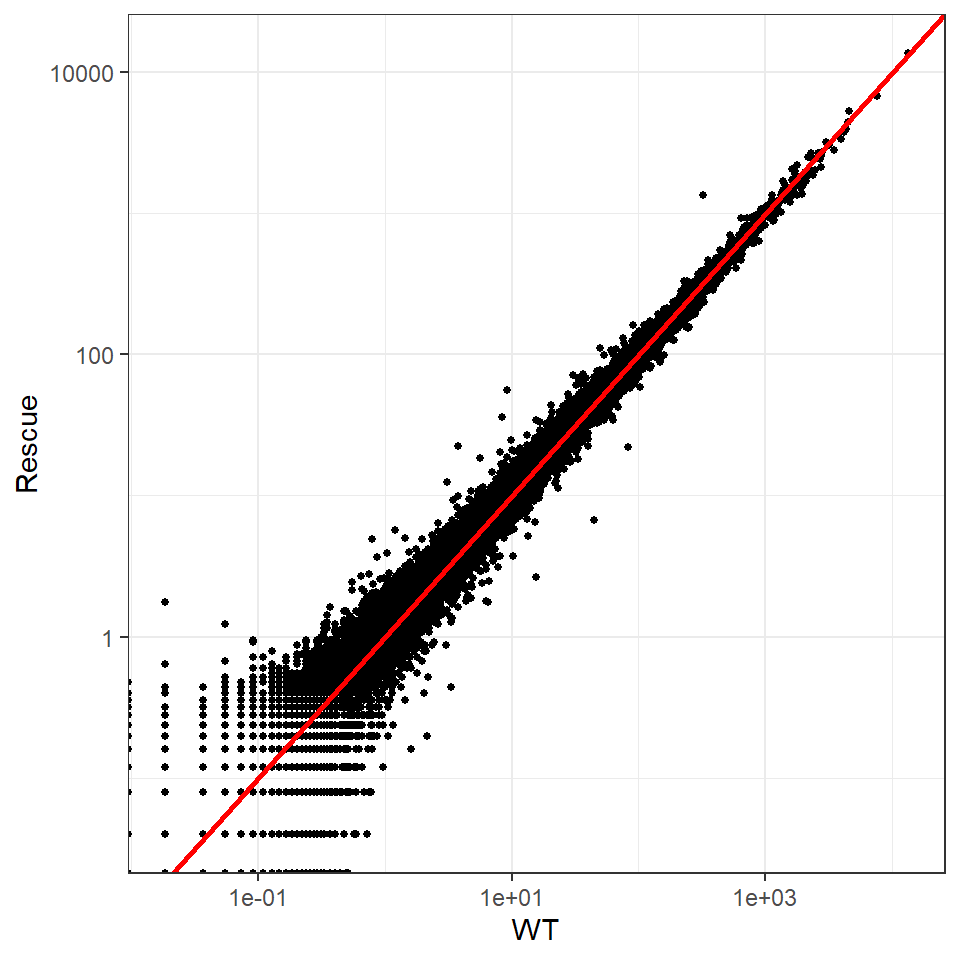

```r
global %>%
  ggplot(aes(x=WT, y=Rescue)) +
  geom_point(size=1) +
  scale_x_log10() + scale_y_log10() +
  geom_abline(slope=1, intercept=0, colour="red", linewidth=1)
```

For the WT vs Rescue we can see the previous global offset is now fixed.

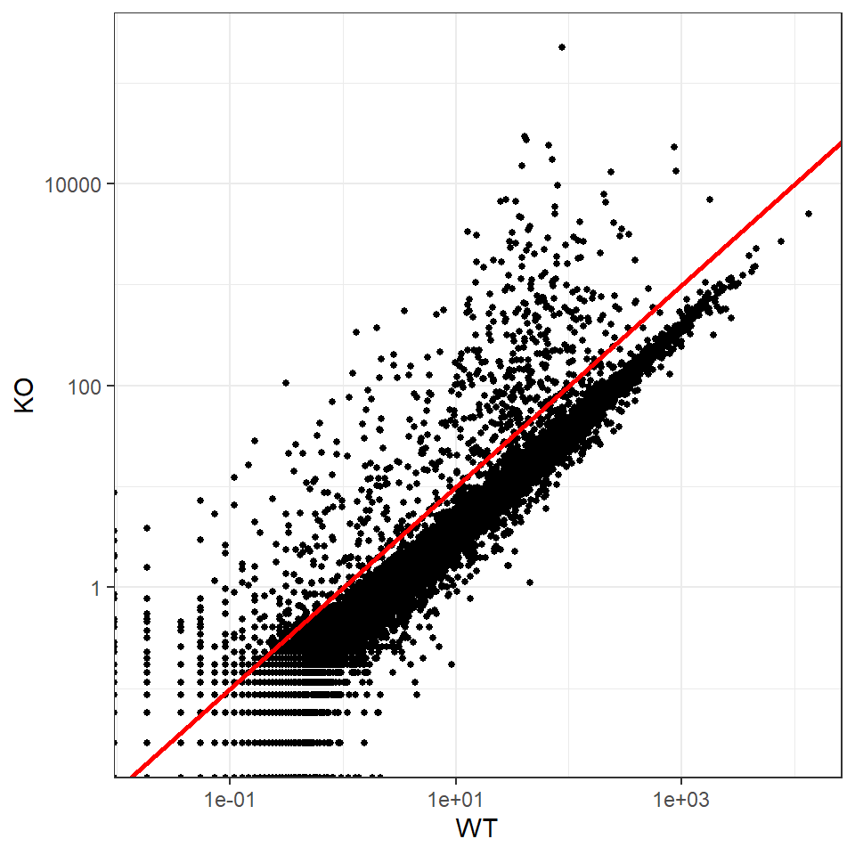

```r
global %>%
  ggplot(aes(x=WT, y=KO)) +
  geom_point(size=1) +
  scale_x_log10() + scale_y_log10() +
  geom_abline(slope=1, intercept=0, colour="red", linewidth=1)
```

# Size Factor Normalisation

We’re going to try size factor normalisation. We’ll do this in distinct steps

1. Create an “average” sample
2. Calulate the difference from each point in each sample to the “average”
3. Find the median difference for each sample
4. Use this difference to correct the values in each sample

## Creating an average sample

We’ll start by making an average sample. We only want to do this for points which have a real measurement in all samples so we’ll remove any gene which has zero counts in any condition. We don’t need data from all genes to calculate a size factor.

```r
data_long %>%
  group_by(gene) %>%
  filter(all(count > 0)) %>%
  summarise(
    average_count=mean(count)
  ) %>%
  ungroup() -> average_sample

head(average_sample)
```

| gene | average_count |
| --- | --- |
| gene_1000 | 594.33333 |
| gene_10009 | 58.66667 |
| gene_1001 | 1858.33333 |
| gene_10010 | 2038.66667 |
| gene_10013 | 26.66667 |
| gene_10014 | 1179.66667 |

## Calculate differences to average

```r
data_long %>%
  inner_join(average_sample) %>%
  mutate(difference=count/average_count) -> differences
head(differences)
```

| gene | sample | count | average_count | difference |
| --- | --- | --- | --- | --- |
| gene_15 | KO | 11 | 24.000000 | 0.4583333 |
| gene_15 | Rescue | 22 | 24.000000 | 0.9166667 |
| gene_15 | WT | 39 | 24.000000 | 1.6250000 |
| gene_16 | KO | 3 | 5.666667 | 0.5294118 |
| gene_16 | Rescue | 6 | 5.666667 | 1.0588235 |
| gene_16 | WT | 8 | 5.666667 | 1.4117647 |

Now we can look at the distribution of differences for each sample

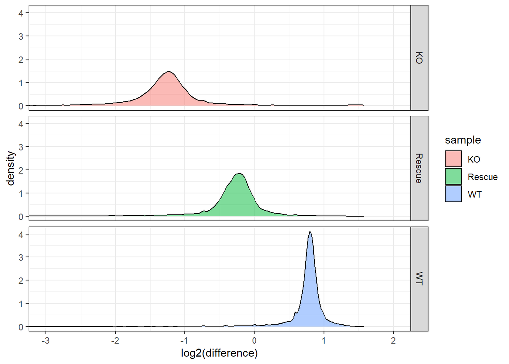

```r
differences %>%
  ggplot(aes(x=log2(difference), fill=sample)) +
  geom_density(alpha=0.5) +
  facet_grid(
    rows=vars(sample)
  ) +
  coord_cartesian(xlim=c(-3,2))
```

## Calcualte size factors

The size factor is simply the median difference for each sample

```r
differences %>%
  group_by(sample) %>%
  summarise(size_factor=median(difference)) -> size_factors

size_factors
```

| sample | size_factor |
| --- | --- |
| KO | 0.4200000 |
| Rescue | 0.8353402 |
| WT | 1.7317170 |

## Apply size factors to the data

We can now use the size factors as the correction factor for the full dataset.

```r
data_long %>%
  left_join(size_factors) %>%
  mutate(normalised=count/size_factor) %>%
  select(-count, -size_factor) %>%
  pivot_wider(
    names_from=sample,
    values_from=normalised
  ) -> sf_normalised
```

We can plot the scatterplots one last time.

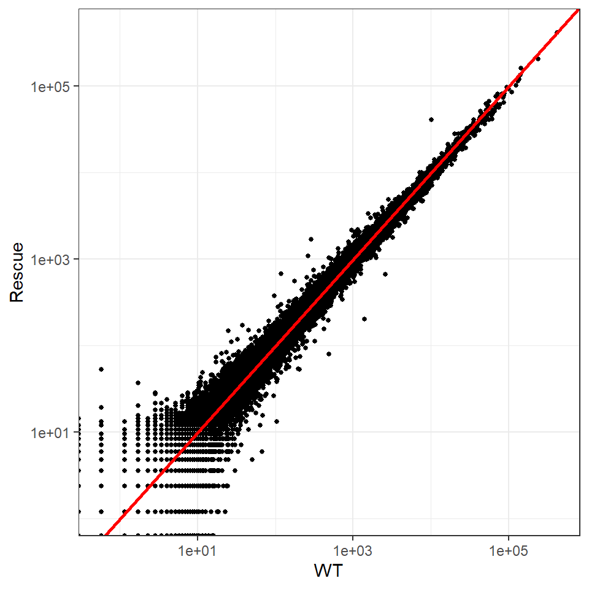

```r
sf_normalised %>%
  ggplot(aes(x=WT, y=Rescue)) +
  geom_point(size=1) +
  scale_x_log10() + scale_y_log10() +
  geom_abline(slope=1, intercept=0, colour="red", linewidth=1)
```

For the WT vs Rescue we can see the previous global offset is now fixed.

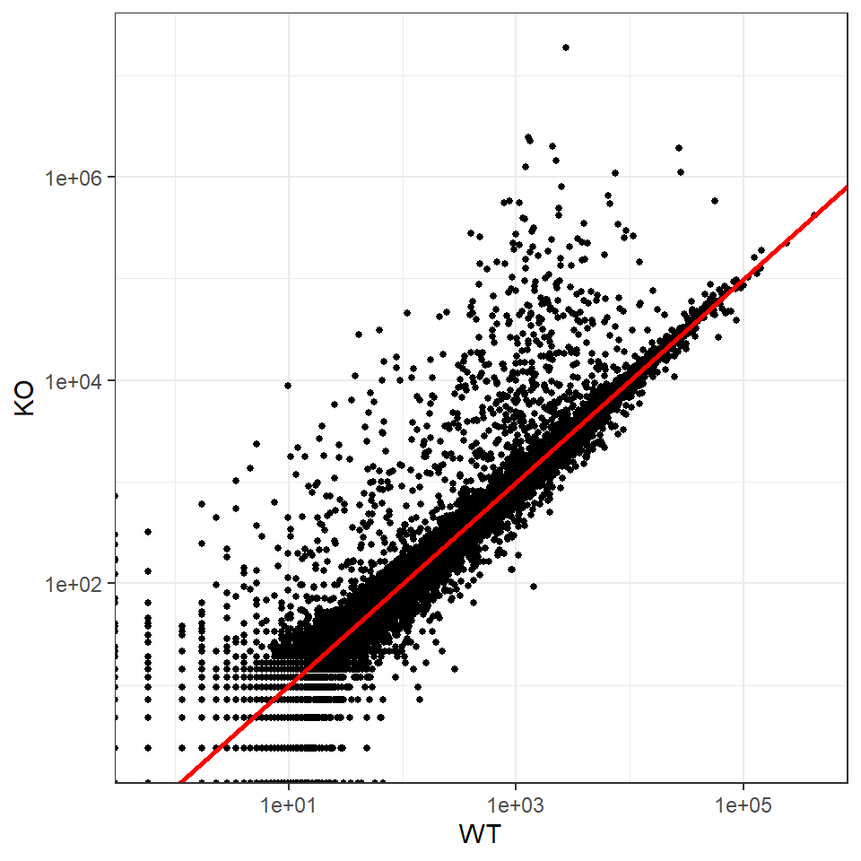

```r
sf_normalised %>%
  ggplot(aes(x=WT, y=KO)) +
  geom_point(size=1) +
  scale_x_log10() + scale_y_log10() +
  geom_abline(slope=1, intercept=0, colour="red", linewidth=1)
```